# AIML_ML_Project_full_code_notebook_Rohit_Kumar

- Accuracy (97.93% in Test and 99.08% in Train dataset)
  - The model correctly classified 97.93% of the test dataset.
  - High accuracy suggests strong predictive performance and effective generalization to unseen data.
  - However, it is important to consider recall and precision separately, especially when predicting loan takers.
- Precision (91.00% in Test and 95.16% in Train dataset)
  - Precision measures how many of the predicted loan takers were actually correct.
  - A high precision means fewer false positives, which is crucial for ensuring that only actual potential loan customers are targeted.
  - The 91% precision suggests the model is very effective at avoiding unnecessary loan approvals.
- Recall (88.00%in Test and 95.16% in Train dataset)
  - Recall represents the proportion of actual loan takers correctly identified.
  - The recall of 88% means 12% of actual loan customers were missed, which could result in lost revenue opportunities for the bank.
  - Compared to precision, recall is slightly lower, indicating a conservative approach in predicting loan takers.

Post Pruning

```
The best ccp_alpha value for optimal post-pruning is: 0.000641
```

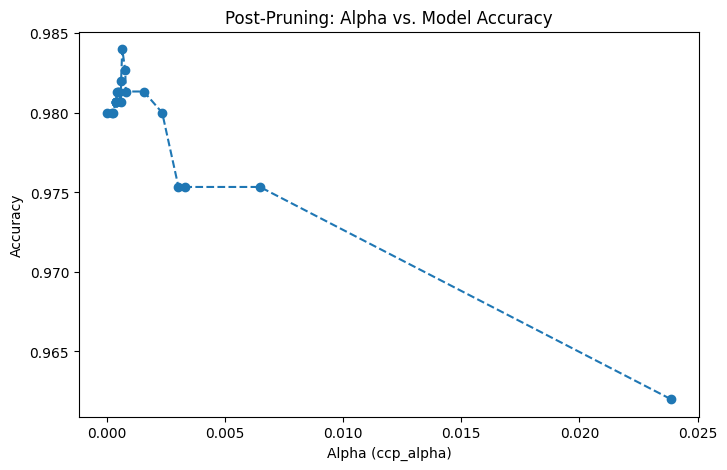

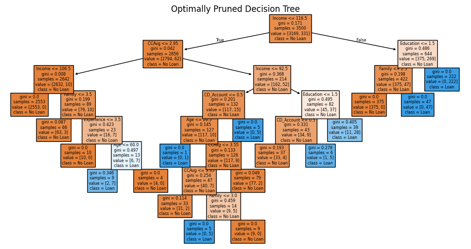

[output not shown]

```python
# Train an overfitted tree to find optimal pruning parameter (ccp_alpha)
model_post_pruned = DecisionTreeClassifier(random_state=1)
model_post_pruned.fit(X_train, Y_train)

# Get cost complexity pruning path
path = model_post_pruned.cost_complexity_pruning_path(X_train, Y_train)
ccp_alphas = path.ccp_alphas

# Train and evaluate models with different alpha values
pruned_models = []
accuracies = []

for alpha in ccp_alphas[:-1]:  # Exclude last value as it prunes everything
    pruned_tree = DecisionTreeClassifier(random_state=1, ccp_alpha=alpha)
    pruned_tree.fit(X_train, Y_train)
    y_pred_pruned = pruned_tree.predict(X_test)
    accuracy = accuracy_score(Y_test, y_pred_pruned)
    pruned_models.append(pruned_tree)
    accuracies.append(accuracy)

# Identify best alpha
best_alpha_index = accuracies.index(max(accuracies))
best_alpha = ccp_alphas[best_alpha_index]
best_pruned_tree = pruned_models[best_alpha_index]

# Print best ccp_alpha value
print(f"The best ccp_alpha value for optimal post-pruning is: {best_alpha:.6f}")

# Plot Alpha vs Accuracy
plt.figure(figsize=(8, 5))
plt.plot(ccp_alphas[:-1], accuracies, marker="o", linestyle="--")
plt.xlabel("Alpha (ccp_alpha)")
plt.ylabel("Accuracy")
plt.title("Post-Pruning: Alpha vs. Model Accuracy")
plt.show()

# Final Evaluation of the Best Pruned Tree
y_pred_best_pruned = best_pruned_tree.predict(X_test)
accuracy_best_pruned = accuracy_score(Y_test, y_pred_best_pruned)

# Display Pruned Tree
plt.figure(figsize=(12, 6))
plot_tree(best_pruned_tree, feature_names=X.columns, class_names=['No Loan', 'Loan'], filled=True)
plt.title("Optimally Pruned Decision Tree")
plt.show()

report_post = classification_report(Y_test, y_pred_post)


print("Classification Report:")
print(report_post)
```

Observation :-

- Accuracy improved slightly to 98%.
- Precision and recall for loan buyers (class 1) improved, suggesting better generalization.
- Pruning helped in reducing complexity without compromising accuracy.
- The pruned model generalizes slightly better to new data, improving its ability to correctly identify potential loan buyers.

## Model Performance Comparison and Final Model Selection

```python
# Train Decision Tree with Pre-Pruning
model_pre_pruned = DecisionTreeClassifier(max_depth=5, min_samples_split=20, random_state=1)
model_pre_pruned.fit(X_train, Y_train)

# Predictions for Pre-Pruned Model
y_pred_pre = model_pre_pruned.predict(X_test)
accuracy_pre_pruned = accuracy_score(Y_test, y_pred_pre)
report_pre_pruned = classification_report(Y_test, y_pred_pre, output_dict=True)

# Train Decision Tree with Post-Pruning (Optimized Hyperparameters)
model_post_pruned = DecisionTreeClassifier(random_state=1)
model_post_pruned.fit(X_train, Y_train)

# Get cost complexity pruning path
path = model_post_pruned.cost_complexity_pruning_path(X_train, Y_train)
ccp_alphas = path.ccp_alphas

# Train and evaluate models with different alpha values
pruned_models = []
accuracies = []

for alpha in ccp_alphas[:-1]:  # Exclude last value as it prunes everything
    pruned_tree = DecisionTreeClassifier(random_state=1, ccp_alpha=alpha)
    pruned_tree.fit(X_train, Y_train)
    y_pred_pruned = pruned_tree.predict(X_test)
    accuracy = accuracy_score(Y_test, y_pred_pruned)
    pruned_models.append(pruned_tree)
    accuracies.append(accuracy)

# Identify best alpha (corresponding to highest accuracy)
best_alpha_index = accuracies.index(max(accuracies))
best_alpha = ccp_alphas[best_alpha_index]
best_pruned_tree = pruned_models[best_alpha_index]

# Print best ccp_alpha value
print(f"The best ccp_alpha value for optimal post-pruning is: {best_alpha:.6f}")

# Create comparison table
comparison_data = {
    "Metric": ["Accuracy", "Precision (Loan=1)", "Recall (Loan=1)", "F1-score (Loan=1)"],
    "Pre-Pruning (max_depth=5, min_samples_split=20)": [
        accuracy_pre_pruned,
        report_pre_pruned["1"]["precision"],
        report_pre_pruned["1"]["recall"],
        report_pre_pruned["1"]["f1-score"]
    ],
    "Post-Pruning (best ccp_alpha)": [
        accuracy_score(Y_test, best_pruned_tree.predict(X_test)),
        classification_report(Y_test, best_pruned_tree.predict(X_test), output_dict=True)["1"]["precision"],
        classification_report(Y_test, best_pruned_tree.predict(X_test), output_dict=True)["1"]["recall"],
        classification_report(Y_test, best_pruned_tree.predict(X_test), output_dict=True)["1"]["f1-score"]
    ]
}

# Convert to DataFrame and display
comparison_df = pd.DataFrame(comparison_data)
print(comparison_df)
# Observations
```

```
The best ccp_alpha value for optimal post-pruning is: 0.000641
               Metric  Pre-Pruning (max_depth=5, min_samples_split=20)  \
0            Accuracy                                         0.979333
1  Precision (Loan=1)                                         0.909722
2     Recall (Loan=1)                                         0.879195
3   F1-score (Loan=1)                                         0.894198

   Post-Pruning (best ccp_alpha)
0                       0.984000
1                       0.931034
2                       0.906040
3                       0.918367
```

## Actionable Insights and Business Recommendations

1. Income :-

Customers with income above $100K are far more likely to accept a personal loan. Higher-income customers are financially stable and may take loans for investments, luxury purchases, or business purposes.

2. Credit Card Spending :-

Customers spending above $2K/month on credit cards show a higher likelihood of taking loans. This suggests they are comfortable using credit and may require additional liquidity.

3. Customers with CD Accounts :-

Holding a Certificate of Deposit (CD) account correlates with higher loan acceptance. These customers trust the bank and may be open to bundled financial products.

4. Higher Education Increases Loan Acceptance

Customers with Graduate or Advanced degrees are more likely to take loans. These customers tend to have stable jobs and higher earning potential, making them ideal candidates.

5. Online Banking Users Show Higher Engagement

Customers who actively use online banking are more likely to accept a loan. Digital engagement suggests openness to automated, paperless loan offers.

6. Mortgage Holders Show Some Interest in Loans

Customers with existing mortgages may be interested in home improvement or refinancing loans. However, mortgage size alone is not the best predictor of loan acceptance.

## Business Recoomendations

Loan Campaign :-

- Use predictive analytics to focus on high-income earners, credit card spenders, and CD account holders.
- Prioritize these customers for loan pre-approvals with competitive rates.

Segmented Marketing Messages :-

- High-Income Professionals: Offer loans for investments, education, or business expansion.
- Online Banking Users: Display loan offers within the mobile banking app for easy application.
- Mortgage Holders: Promote home improvement loans or refinancing options.

Flexible Interest Rate Options :-

- Provide tiered interest rates based on income and credit history to attract high-quality borrowers.

Instant Digital Loan Approvals :-

- Enable a seamless digital application process for online banking users.
- Use a pre-approval system based on customer spending and income patterns.

Strengthen Customer Engagement & Awareness :-

- Proactive Outreach via Relationship Managers
  - Assign personal banking advisors to high-value customers.

Bundle Loan Offers with CD Accounts :-

- Offer preferential loan rates for customers with CD accounts.